# ML5: Predicting Page Views

Wong Yat Chun

2018 M01 5

The case study will focus on using regression to predict the amount of page views for the top 1000 websites on the Internet as of 2011.

Import Library

```r
library(ggplot2)
```

We will start by making a scatterplot that relates PageViews with UniqueVisitors. Drawing scatterplots for numerical variablers before try to relate them by using regressing because a scatterplot can make it clear when the linearity assumption of regression isn’t satisfied

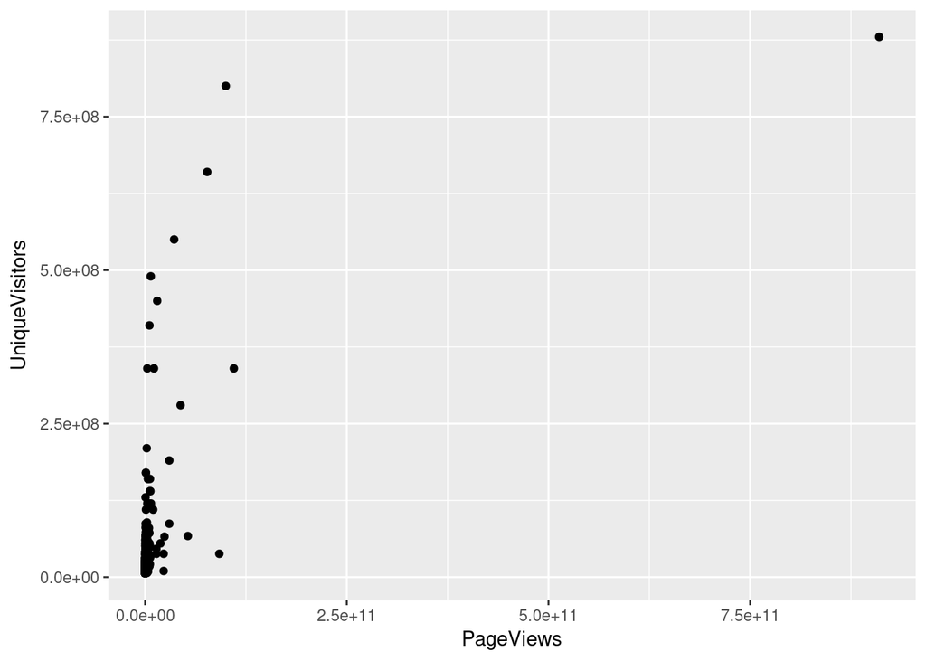

```r
top.1000.sites <- read.csv('data/top_1000_sites.tsv',
                           sep='\t',
                           stringsAsFactors = F)
ggplot(top.1000.sites,aes(x=PageViews,y=UniqueVisitors))+
  geom_point()
```

It looks bad, this is a common problem when working with data that;s not normally distributed, because using a scale that’s large enough to show the full range of values tends to place the majority of data points so close to each other that they can’t be separated visually.

One feasible way to tackle to problem is to change the scale by performing log-transformation

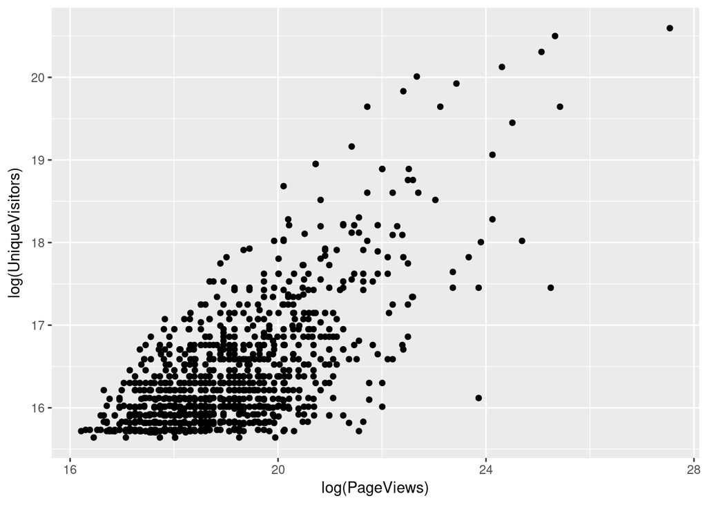

```r
ggplot(top.1000.sites,aes(x=log(PageViews),y=log(UniqueVisitors)))+
  geom_point()
```

The ggplot2 package also contains a convenience function to change the scale of an axis to the log. You can use the scale_x_log or scale_y_log in this case. Also, recall from our discussion in Chapter 4 that in some cases you will want to use the logp function in R to avoid the errors related to taking the log of zero. In this case, however, that is not a problem.

The resulting scatterplot looks like there’s a potential line to be drawn using regression. Before we use lm to fit a regression line, we can use geom_smooth with the method = ‘lm’ argument to see what the regression line will look like

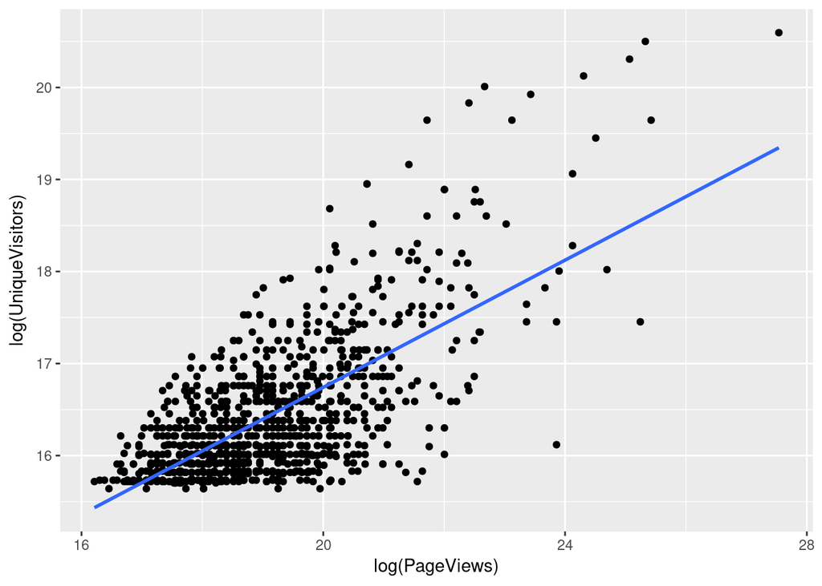

```r
ggplot(top.1000.sites,aes(x=log(PageViews),y=log(UniqueVisitors)))+
  geom_point()+
  geom_smooth(method='lm',se=F)
```

Find the values that defines the line’s slope and intercept by calling lm

```r
lm.fit <- lm(log(PageViews)~log(UniqueVisitors),
             data=top.1000.sites)
summary(lm.fit)
```

```
##
## Call:
## lm(formula = log(PageViews) ~ log(UniqueVisitors), data = top.1000.sites)
##
## Residuals:
##     Min      1Q  Median      3Q     Max
## -2.1825 -0.7986 -0.0741  0.6467  5.1549
##
## Coefficients:
##                     Estimate Std. Error t value Pr(>|t|)
## (Intercept)         -2.83441    0.75201  -3.769 0.000173 ***
## log(UniqueVisitors)  1.33628    0.04568  29.251  < 2e-16 ***
## ---
## Signif. codes:  0 '***' 0.001 '**' 0.01 '*' 0.05 '.' 0.1 ' ' 1
##
## Residual standard error: 1.084 on 998 degrees of freedom
## Multiple R-squared:  0.4616, Adjusted R-squared:  0.4611
## F-statistic: 855.6 on 1 and 998 DF,  p-value: < 2.2e-16
```

```r
lm.fit <- lm(log(PageViews) ~ HasAdvertising + log(UniqueVisitors) + InEnglish,
data = top.1000.sites)
summary(lm.fit)
```

```
##
## Call:
## lm(formula = log(PageViews) ~ HasAdvertising + log(UniqueVisitors) +
##     InEnglish, data = top.1000.sites)
##
## Residuals:
##     Min      1Q  Median      3Q     Max
## -2.4283 -0.7685 -0.0632  0.6298  5.4133
##
## Coefficients:
##                     Estimate Std. Error t value Pr(>|t|)
## (Intercept)         -1.94502    1.14777  -1.695  0.09046 .
## HasAdvertisingYes    0.30595    0.09170   3.336  0.00088 ***
## log(UniqueVisitors)  1.26507    0.07053  17.936  < 2e-16 ***
## InEnglishNo          0.83468    0.20860   4.001 6.77e-05 ***
## InEnglishYes        -0.16913    0.20424  -0.828  0.40780
## ---
## Signif. codes:  0 '***' 0.001 '**' 0.01 '*' 0.05 '.' 0.1 ' ' 1
##
## Residual standard error: 1.067 on 995 degrees of freedom
## Multiple R-squared:  0.4798, Adjusted R-squared:  0.4777
## F-statistic: 229.4 on 4 and 995 DF,  p-value: < 2.2e-16
```